# Risk Factor Analysis

## Outcome Variable

**Outcome Variable:** swasted

## Predictor Variables

**Intervention Variable:** impsan

**Adjustment Set:**

- arm
- sex
- W_mage
- meducyrs
- feducyrs
- hhwealth_quart
- hfoodsec
- W_mhtcm
- W_nrooms
- W_nchldlt5
- W_parity
- impfloor
- safeh20
- delta_W_mage
- delta_meducyrs
- delta_feducyrs
- delta_hhwealth_quart
- delta_hfoodsec
- delta_W_mhtcm
- delta_W_nrooms
- delta_W_nchldlt5
- delta_W_parity
- delta_impfloor
- delta_safeh20

## Stratifying Variables

The analysis was stratified on these variable(s):

- agecat
- studyid
- country

## Data Summary

| agecat | studyid | country | impsan | swasted | n_cell | n |
| --- | --- | --- | --- | --- | --- | --- |
| Birth | ki0047075b-MAL-ED | BANGLADESH | 0 | 0 | 35 | 222 |
| Birth | ki0047075b-MAL-ED | BANGLADESH | 0 | 1 | 1 | 222 |
| Birth | ki0047075b-MAL-ED | BANGLADESH | 1 | 0 | 179 | 222 |
| Birth | ki0047075b-MAL-ED | BANGLADESH | 1 | 1 | 7 | 222 |
| Birth | ki0047075b-MAL-ED | BRAZIL | 0 | 0 | 4 | 167 |
| Birth | ki0047075b-MAL-ED | BRAZIL | 0 | 1 | 0 | 167 |
| Birth | ki0047075b-MAL-ED | BRAZIL | 1 | 0 | 163 | 167 |
| Birth | ki0047075b-MAL-ED | BRAZIL | 1 | 1 | 0 | 167 |
| Birth | ki0047075b-MAL-ED | INDIA | 0 | 0 | 93 | 188 |
| Birth | ki0047075b-MAL-ED | INDIA | 0 | 1 | 5 | 188 |
| Birth | ki0047075b-MAL-ED | INDIA | 1 | 0 | 89 | 188 |
| Birth | ki0047075b-MAL-ED | INDIA | 1 | 1 | 1 | 188 |
| Birth | ki0047075b-MAL-ED | NEPAL | 0 | 0 | 1 | 166 |
| Birth | ki0047075b-MAL-ED | NEPAL | 0 | 1 | 0 | 166 |
| Birth | ki0047075b-MAL-ED | NEPAL | 1 | 0 | 161 | 166 |
| Birth | ki0047075b-MAL-ED | NEPAL | 1 | 1 | 4 | 166 |
| Birth | ki0047075b-MAL-ED | PERU | 0 | 0 | 183 | 243 |
| Birth | ki0047075b-MAL-ED | PERU | 0 | 1 | 0 | 243 |
| Birth | ki0047075b-MAL-ED | PERU | 1 | 0 | 60 | 243 |
| Birth | ki0047075b-MAL-ED | PERU | 1 | 1 | 0 | 243 |
| Birth | ki0047075b-MAL-ED | SOUTH AFRICA | 0 | 0 | 208 | 211 |
| Birth | ki0047075b-MAL-ED | SOUTH AFRICA | 0 | 1 | 1 | 211 |
| Birth | ki0047075b-MAL-ED | SOUTH AFRICA | 1 | 0 | 2 | 211 |
| Birth | ki0047075b-MAL-ED | SOUTH AFRICA | 1 | 1 | 0 | 211 |
| Birth | ki0047075b-MAL-ED | TANZANIA, UNITED REPUBLIC OF | 0 | 0 | 108 | 109 |
| Birth | ki0047075b-MAL-ED | TANZANIA, UNITED REPUBLIC OF | 0 | 1 | 1 | 109 |
| Birth | ki0047075b-MAL-ED | TANZANIA, UNITED REPUBLIC OF | 1 | 0 | 0 | 109 |
| Birth | ki0047075b-MAL-ED | TANZANIA, UNITED REPUBLIC OF | 1 | 1 | 0 | 109 |
| Birth | ki1017093-NIH-Birth | BANGLADESH | 0 | 0 | 18 | 28 |
| Birth | ki1017093-NIH-Birth | BANGLADESH | 0 | 1 | 1 | 28 |

[output cut: 166 more lines]

The following strata were considered:

- agecat: 24 months, studyid: ki0047075b-MAL-ED, country: BANGLADESH
- agecat: 24 months, studyid: ki0047075b-MAL-ED, country: BRAZIL
- agecat: 24 months, studyid: ki0047075b-MAL-ED, country: INDIA
- agecat: 24 months, studyid: ki0047075b-MAL-ED, country: NEPAL
- agecat: 24 months, studyid: ki0047075b-MAL-ED, country: PERU
- agecat: 24 months, studyid: ki0047075b-MAL-ED, country: SOUTH AFRICA
- agecat: 24 months, studyid: ki0047075b-MAL-ED, country: TANZANIA, UNITED REPUBLIC OF
- agecat: 24 months, studyid: ki1017093-NIH-Birth, country: BANGLADESH
- agecat: 24 months, studyid: ki1017093b-PROVIDE, country: BANGLADESH
- agecat: 24 months, studyid: ki1017093c-NIH-Crypto, country: BANGLADESH
- agecat: 24 months, studyid: ki1114097-CONTENT, country: PERU
- agecat: 24 months, studyid: ki1135781-COHORTS, country: GUATEMALA
- agecat: 24 months, studyid: ki1135781-COHORTS, country: INDIA
- agecat: 24 months, studyid: ki1135781-COHORTS, country: PHILIPPINES
- agecat: 24 months, studyid: ki1148112-LCNI-5, country: MALAWI
- agecat: 24 months, studyid: kiGH5241-JiVitA-3, country: BANGLADESH
- agecat: 24 months, studyid: kiGH5241-JiVitA-4, country: BANGLADESH
- agecat: 6 months, studyid: ki0047075b-MAL-ED, country: BANGLADESH
- agecat: 6 months, studyid: ki0047075b-MAL-ED, country: BRAZIL
- agecat: 6 months, studyid: ki0047075b-MAL-ED, country: INDIA
- agecat: 6 months, studyid: ki0047075b-MAL-ED, country: NEPAL
- agecat: 6 months, studyid: ki0047075b-MAL-ED, country: PERU
- agecat: 6 months, studyid: ki0047075b-MAL-ED, country: SOUTH AFRICA
- agecat: 6 months, studyid: ki0047075b-MAL-ED, country: TANZANIA, UNITED REPUBLIC OF
- agecat: 6 months, studyid: ki1017093-NIH-Birth, country: BANGLADESH
- agecat: 6 months, studyid: ki1017093b-PROVIDE, country: BANGLADESH
- agecat: 6 months, studyid: ki1017093c-NIH-Crypto, country: BANGLADESH
- agecat: 6 months, studyid: ki1114097-CONTENT, country: PERU
- agecat: 6 months, studyid: ki1135781-COHORTS, country: GUATEMALA
- agecat: 6 months, studyid: ki1135781-COHORTS, country: INDIA
- agecat: 6 months, studyid: ki1135781-COHORTS, country: PHILIPPINES
- agecat: 6 months, studyid: ki1148112-LCNI-5, country: MALAWI
- agecat: 6 months, studyid: kiGH5241-JiVitA-3, country: BANGLADESH
- agecat: 6 months, studyid: kiGH5241-JiVitA-4, country: BANGLADESH
- agecat: Birth, studyid: ki0047075b-MAL-ED, country: BANGLADESH
- agecat: Birth, studyid: ki0047075b-MAL-ED, country: BRAZIL
- agecat: Birth, studyid: ki0047075b-MAL-ED, country: INDIA
- agecat: Birth, studyid: ki0047075b-MAL-ED, country: NEPAL
- agecat: Birth, studyid: ki0047075b-MAL-ED, country: PERU
- agecat: Birth, studyid: ki0047075b-MAL-ED, country: SOUTH AFRICA
- agecat: Birth, studyid: ki0047075b-MAL-ED, country: TANZANIA, UNITED REPUBLIC OF
- agecat: Birth, studyid: ki1017093-NIH-Birth, country: BANGLADESH
- agecat: Birth, studyid: ki1017093c-NIH-Crypto, country: BANGLADESH
- agecat: Birth, studyid: ki1114097-CONTENT, country: PERU
- agecat: Birth, studyid: ki1135781-COHORTS, country: GUATEMALA
- agecat: Birth, studyid: ki1135781-COHORTS, country: INDIA
- agecat: Birth, studyid: ki1135781-COHORTS, country: PHILIPPINES
- agecat: Birth, studyid: kiGH5241-JiVitA-3, country: BANGLADESH
- agecat: Birth, studyid: kiGH5241-JiVitA-4, country: BANGLADESH

### Dropped Strata

Some strata were dropped due to rare outcomes:

- agecat: Birth, studyid: ki0047075b-MAL-ED, country: BANGLADESH
- agecat: Birth, studyid: ki0047075b-MAL-ED, country: BRAZIL
- agecat: Birth, studyid: ki0047075b-MAL-ED, country: INDIA
- agecat: Birth, studyid: ki0047075b-MAL-ED, country: NEPAL
- agecat: Birth, studyid: ki0047075b-MAL-ED, country: PERU
- agecat: Birth, studyid: ki0047075b-MAL-ED, country: SOUTH AFRICA
- agecat: Birth, studyid: ki0047075b-MAL-ED, country: TANZANIA, UNITED REPUBLIC OF
- agecat: Birth, studyid: ki1017093-NIH-Birth, country: BANGLADESH
- agecat: Birth, studyid: ki1017093c-NIH-Crypto, country: BANGLADESH
- agecat: Birth, studyid: ki1114097-CONTENT, country: PERU
- agecat: Birth, studyid: kiGH5241-JiVitA-4, country: BANGLADESH
- agecat: 6 months, studyid: ki0047075b-MAL-ED, country: BANGLADESH
- agecat: 6 months, studyid: ki0047075b-MAL-ED, country: BRAZIL
- agecat: 6 months, studyid: ki0047075b-MAL-ED, country: INDIA
- agecat: 6 months, studyid: ki0047075b-MAL-ED, country: NEPAL
- agecat: 6 months, studyid: ki0047075b-MAL-ED, country: PERU
- agecat: 6 months, studyid: ki0047075b-MAL-ED, country: SOUTH AFRICA
- agecat: 6 months, studyid: ki0047075b-MAL-ED, country: TANZANIA, UNITED REPUBLIC OF
- agecat: 6 months, studyid: ki1017093-NIH-Birth, country: BANGLADESH
- agecat: 6 months, studyid: ki1017093b-PROVIDE, country: BANGLADESH
- agecat: 6 months, studyid: ki1017093c-NIH-Crypto, country: BANGLADESH
- agecat: 6 months, studyid: ki1114097-CONTENT, country: PERU
- agecat: 6 months, studyid: ki1135781-COHORTS, country: GUATEMALA
- agecat: 6 months, studyid: ki1135781-COHORTS, country: PHILIPPINES
- agecat: 6 months, studyid: ki1148112-LCNI-5, country: MALAWI
- agecat: 24 months, studyid: ki0047075b-MAL-ED, country: BANGLADESH
- agecat: 24 months, studyid: ki0047075b-MAL-ED, country: BRAZIL
- agecat: 24 months, studyid: ki0047075b-MAL-ED, country: INDIA
- agecat: 24 months, studyid: ki0047075b-MAL-ED, country: NEPAL
- agecat: 24 months, studyid: ki0047075b-MAL-ED, country: PERU
- agecat: 24 months, studyid: ki0047075b-MAL-ED, country: SOUTH AFRICA
- agecat: 24 months, studyid: ki0047075b-MAL-ED, country: TANZANIA, UNITED REPUBLIC OF
- agecat: 24 months, studyid: ki1017093-NIH-Birth, country: BANGLADESH
- agecat: 24 months, studyid: ki1017093b-PROVIDE, country: BANGLADESH
- agecat: 24 months, studyid: ki1017093c-NIH-Crypto, country: BANGLADESH
- agecat: 24 months, studyid: ki1114097-CONTENT, country: PERU
- agecat: 24 months, studyid: ki1135781-COHORTS, country: GUATEMALA
- agecat: 24 months, studyid: ki1135781-COHORTS, country: PHILIPPINES
- agecat: 24 months, studyid: ki1148112-LCNI-5, country: MALAWI

## Methods Detail

We’re interested in the causal parameters $E[Y_a]$ for all values of $a \in \mathcal{A}$. These parameters represent the mean outcome if, possibly contrary to fact, we intervened to set all units to have $A=a$. Under the randomization and positivity assumptions, these are identified by the statistical parameters $\psi_a=E_W[E_{Y|A,W}(Y|A=a,W)]$. In addition, we’re interested in the mean of $Y$, $E[Y]$ under no intervention (the observed mean). We will estimate these parameters by using SuperLearner to fit the relevant likelihood factors – $E_{Y|A,W}(Y|A=a,W)$ and $p(A=a|W)$, and then updating our likelihood fit using a joint TMLE.

For unadjusted analyses ($W=\{\}$), initial likelihoods were estimated using Lrnr_glm to estimate the simple $E(Y|A)$ and Lrnr_mean to estimate $p(A)$. For adjusted analyses, a small library containing Lrnr_glmnet, Lrnr_xgboost, and Lrnr_mean was used.

Having estimated these parameters, we will then use the delta method to estimate relative risks and attributable risks relative to a prespecified baseline level of $A$.

# Results Detail

## Results Plots

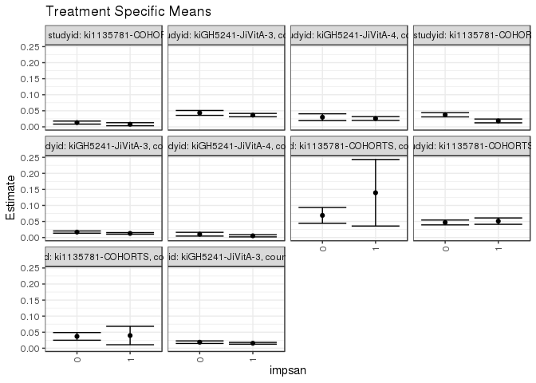

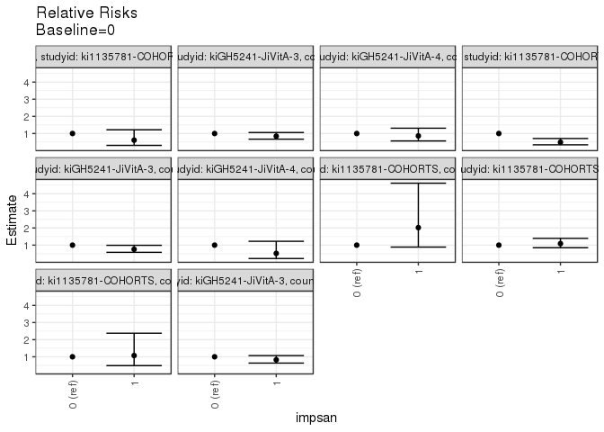

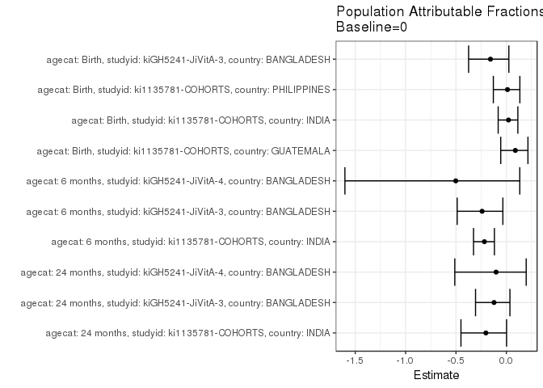

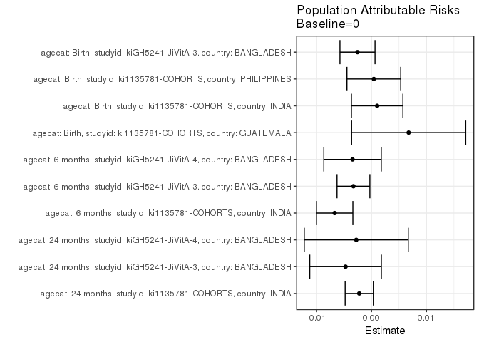

## Results Table

### Parameter: TSM

| agecat | studyid | country | intervention_level | baseline_level | estimate | ci_lower | ci_upper |
| --- | --- | --- | --- | --- | --- | --- | --- |
| Birth | ki1135781-COHORTS | GUATEMALA | 0 | NA | 0.0689655 | 0.0442899 | 0.0936411 |
| Birth | ki1135781-COHORTS | GUATEMALA | 1 | NA | 0.1395349 | 0.0358522 | 0.2432175 |
| Birth | ki1135781-COHORTS | INDIA | 0 | NA | 0.0469457 | 0.0394413 | 0.0544501 |
| Birth | ki1135781-COHORTS | INDIA | 1 | NA | 0.0511337 | 0.0412360 | 0.0610315 |
| Birth | ki1135781-COHORTS | PHILIPPINES | 0 | NA | 0.0368809 | 0.0248846 | 0.0488773 |
| Birth | ki1135781-COHORTS | PHILIPPINES | 1 | NA | 0.0395480 | 0.0108234 | 0.0682727 |
| Birth | kiGH5241-JiVitA-3 | BANGLADESH | 0 | NA | 0.0187443 | 0.0147931 | 0.0226955 |
| Birth | kiGH5241-JiVitA-3 | BANGLADESH | 1 | NA | 0.0154249 | 0.0126884 | 0.0181614 |
| 6 months | ki1135781-COHORTS | INDIA | 0 | NA | 0.0375362 | 0.0309826 | 0.0440899 |
| 6 months | ki1135781-COHORTS | INDIA | 1 | NA | 0.0184123 | 0.0125111 | 0.0243135 |
| 6 months | kiGH5241-JiVitA-3 | BANGLADESH | 0 | NA | 0.0169630 | 0.0135068 | 0.0204192 |
| 6 months | kiGH5241-JiVitA-3 | BANGLADESH | 1 | NA | 0.0128510 | 0.0104124 | 0.0152895 |
| 6 months | kiGH5241-JiVitA-4 | BANGLADESH | 0 | NA | 0.0103353 | 0.0045170 | 0.0161536 |
| 6 months | kiGH5241-JiVitA-4 | BANGLADESH | 1 | NA | 0.0053686 | 0.0019469 | 0.0087903 |
| 24 months | ki1135781-COHORTS | INDIA | 0 | NA | 0.0132456 | 0.0085244 | 0.0179669 |
| 24 months | ki1135781-COHORTS | INDIA | 1 | NA | 0.0080895 | 0.0033164 | 0.0128625 |
| 24 months | kiGH5241-JiVitA-3 | BANGLADESH | 0 | NA | 0.0433897 | 0.0358402 | 0.0509393 |
| 24 months | kiGH5241-JiVitA-3 | BANGLADESH | 1 | NA | 0.0365088 | 0.0312725 | 0.0417451 |
| 24 months | kiGH5241-JiVitA-4 | BANGLADESH | 0 | NA | 0.0300584 | 0.0194799 | 0.0406368 |
| 24 months | kiGH5241-JiVitA-4 | BANGLADESH | 1 | NA | 0.0258787 | 0.0199937 | 0.0317637 |

### Parameter: E(Y)

| agecat | studyid | country | intervention_level | baseline_level | estimate | ci_lower | ci_upper |
| --- | --- | --- | --- | --- | --- | --- | --- |
| Birth | ki1135781-COHORTS | GUATEMALA | NA | NA | 0.0757238 | 0.0512261 | 0.1002216 |
| Birth | ki1135781-COHORTS | INDIA | NA | NA | 0.0479713 | 0.0416994 | 0.0542432 |
| Birth | ki1135781-COHORTS | PHILIPPINES | NA | NA | 0.0373002 | 0.0262270 | 0.0483734 |
| Birth | kiGH5241-JiVitA-3 | BANGLADESH | NA | NA | 0.0161897 | 0.0138244 | 0.0185550 |
| 6 months | ki1135781-COHORTS | INDIA | NA | NA | 0.0308219 | 0.0260134 | 0.0356304 |
| 6 months | kiGH5241-JiVitA-3 | BANGLADESH | NA | NA | 0.0136712 | 0.0115942 | 0.0157483 |
| 6 months | kiGH5241-JiVitA-4 | BANGLADESH | NA | NA | 0.0068819 | 0.0035739 | 0.0101900 |
| 24 months | ki1135781-COHORTS | INDIA | NA | NA | 0.0110097 | 0.0076578 | 0.0143615 |
| 24 months | kiGH5241-JiVitA-3 | BANGLADESH | NA | NA | 0.0386634 | 0.0343339 | 0.0429929 |
| 24 months | kiGH5241-JiVitA-4 | BANGLADESH | NA | NA | 0.0272816 | 0.0219894 | 0.0325738 |

### Parameter: RR

| agecat | studyid | country | intervention_level | baseline_level | estimate | ci_lower | ci_upper |
| --- | --- | --- | --- | --- | --- | --- | --- |
| Birth | ki1135781-COHORTS | GUATEMALA | 0 | 0 | 1.0000000 | 1.0000000 | 1.0000000 |
| Birth | ki1135781-COHORTS | GUATEMALA | 1 | 0 | 2.0232558 | 0.8869142 | 4.6155132 |
| Birth | ki1135781-COHORTS | INDIA | 0 | 0 | 1.0000000 | 1.0000000 | 1.0000000 |
| Birth | ki1135781-COHORTS | INDIA | 1 | 0 | 1.0892110 | 0.8488986 | 1.3975529 |
| Birth | ki1135781-COHORTS | PHILIPPINES | 0 | 0 | 1.0000000 | 1.0000000 | 1.0000000 |
| Birth | ki1135781-COHORTS | PHILIPPINES | 1 | 0 | 1.0723164 | 0.4838357 | 2.3765558 |
| Birth | kiGH5241-JiVitA-3 | BANGLADESH | 0 | 0 | 1.0000000 | 1.0000000 | 1.0000000 |
| Birth | kiGH5241-JiVitA-3 | BANGLADESH | 1 | 0 | 0.8229117 | 0.6321049 | 1.0713154 |
| 6 months | ki1135781-COHORTS | INDIA | 0 | 0 | 1.0000000 | 1.0000000 | 1.0000000 |
| 6 months | ki1135781-COHORTS | INDIA | 1 | 0 | 0.4905216 | 0.3405304 | 0.7065786 |
| 6 months | kiGH5241-JiVitA-3 | BANGLADESH | 0 | 0 | 1.0000000 | 1.0000000 | 1.0000000 |
| 6 months | kiGH5241-JiVitA-3 | BANGLADESH | 1 | 0 | 0.7575896 | 0.5799375 | 0.9896619 |
| 6 months | kiGH5241-JiVitA-4 | BANGLADESH | 0 | 0 | 1.0000000 | 1.0000000 | 1.0000000 |
| 6 months | kiGH5241-JiVitA-4 | BANGLADESH | 1 | 0 | 0.5194410 | 0.2201979 | 1.2253475 |
| 24 months | ki1135781-COHORTS | INDIA | 0 | 0 | 1.0000000 | 1.0000000 | 1.0000000 |
| 24 months | ki1135781-COHORTS | INDIA | 1 | 0 | 0.6107264 | 0.3065416 | 1.2167574 |
| 24 months | kiGH5241-JiVitA-3 | BANGLADESH | 0 | 0 | 1.0000000 | 1.0000000 | 1.0000000 |
| 24 months | kiGH5241-JiVitA-3 | BANGLADESH | 1 | 0 | 0.8414155 | 0.6696388 | 1.0572565 |
| 24 months | kiGH5241-JiVitA-4 | BANGLADESH | 0 | 0 | 1.0000000 | 1.0000000 | 1.0000000 |
| 24 months | kiGH5241-JiVitA-4 | BANGLADESH | 1 | 0 | 0.8609491 | 0.5658262 | 1.3100018 |

### Parameter: PAR

| agecat | studyid | country | intervention_level | baseline_level | estimate | ci_lower | ci_upper |
| --- | --- | --- | --- | --- | --- | --- | --- |
| Birth | ki1135781-COHORTS | GUATEMALA | 0 | NA | 0.0067583 | -0.0036281 | 0.0171447 |
| Birth | ki1135781-COHORTS | INDIA | 0 | NA | 0.0010256 | -0.0036606 | 0.0057118 |
| Birth | ki1135781-COHORTS | PHILIPPINES | 0 | NA | 0.0004193 | -0.0044744 | 0.0053129 |
| Birth | kiGH5241-JiVitA-3 | BANGLADESH | 0 | NA | -0.0025546 | -0.0057457 | 0.0006365 |
| 6 months | ki1135781-COHORTS | INDIA | 0 | NA | -0.0067143 | -0.0100317 | -0.0033969 |
| 6 months | kiGH5241-JiVitA-3 | BANGLADESH | 0 | NA | -0.0032918 | -0.0062817 | -0.0003018 |
| 6 months | kiGH5241-JiVitA-4 | BANGLADESH | 0 | NA | -0.0034534 | -0.0086798 | 0.0017731 |
| 24 months | ki1135781-COHORTS | INDIA | 0 | NA | -0.0022360 | -0.0048014 | 0.0003295 |
| 24 months | kiGH5241-JiVitA-3 | BANGLADESH | 0 | NA | -0.0047263 | -0.0112395 | 0.0017869 |
| 24 months | kiGH5241-JiVitA-4 | BANGLADESH | 0 | NA | -0.0027768 | -0.0122399 | 0.0066863 |

### Parameter: PAF

| agecat | studyid | country | intervention_level | baseline_level | estimate | ci_lower | ci_upper |
| --- | --- | --- | --- | --- | --- | --- | --- |
| Birth | ki1135781-COHORTS | GUATEMALA | 0 | NA | 0.0892495 | -0.0557491 | 0.2143337 |
| Birth | ki1135781-COHORTS | INDIA | 0 | NA | 0.0213803 | -0.0811314 | 0.1141719 |
| Birth | ki1135781-COHORTS | PHILIPPINES | 0 | NA | 0.0112399 | -0.1290129 | 0.1340696 |
| Birth | kiGH5241-JiVitA-3 | BANGLADESH | 0 | NA | -0.1577917 | -0.3745633 | 0.0247945 |
| 6 months | ki1135781-COHORTS | INDIA | 0 | NA | -0.2178415 | -0.3258865 | -0.1186010 |
| 6 months | kiGH5241-JiVitA-3 | BANGLADESH | 0 | NA | -0.2407797 | -0.4880879 | -0.0345722 |
| 6 months | kiGH5241-JiVitA-4 | BANGLADESH | 0 | NA | -0.5018013 | -1.6023313 | 0.1333128 |
| 24 months | ki1135781-COHORTS | INDIA | 0 | NA | -0.2030900 | -0.4505000 | 0.0021196 |
| 24 months | kiGH5241-JiVitA-3 | BANGLADESH | 0 | NA | -0.1222430 | -0.3058179 | 0.0355244 |
| 24 months | kiGH5241-JiVitA-4 | BANGLADESH | 0 | NA | -0.1017824 | -0.5117540 | 0.1970093 |